# altSEE panels - illustrated for proteomics data analysis

Lieven Clement

Ghent University.

lieven.clement@ugent.be

17 June 2026

#### Package

altSEE 0.0.99

# 1 Overview

The *iSEE* package provides a general and flexible framework for interactively exploring `SummarizedExperiment` objects. However, in many cases, more specialized panels are required for effective visualization of specific data types. The `altSEE` package extends the `iSEE` interactive visualisation framework to support exploration of data stored in *alternative experiments* (`altExp`) within a `SingleCellExperiment` (SCE) object.

This vignette illustrates `altSEE` on mass spectrometry-based proteomics. Particularly we will use the **protein** to link protein abundances in the main experiment that were obtained upon summarisation of their corresponding peptides that are stored in the altExp.

We first load in the package:

```r
library("iSEEu")
library("altSEE")
library("QFeatures")
library("msqrob2")
library("SingleCellExperiment")
library("scater")
library("BiocFileCache")
```

## 1.1 Overview

- Import MS-based proteomics data
- Data processing using `QFeatures`
- Differential abundance analysis using `msqrob2`
- Launch an `altSEE` app to explore the DA proteins and their corresponding peptide intensities, interactively.

# 2 Differential abundance

To demonstrate the use of these panels we will perform a differential abundance analysis on the Shen data containing 5 spike-in conditions (a, b, c, d and e) PRIDE identifierPXD003881 (Shen et al. 2018). The data is used in the first chapter of our [msqrob2book](https://statomics.github.io/msqrob2book/01-basics.html). Here we will only use spike-in conditions (a-c) for illustration purposes.

```r
bfc <- BiocFileCache()
peptideFile <- bfcrpath(bfc,"https://github.com/statOmics/msqrob2data/raw/refs/heads/main/dda/shen/peptides.txt")
```

The quantitative columns in maxQuant start with “Intensity.” (note the dot!).

```r
peptides <- data.table::fread(peptideFile, check.names = TRUE, integer64 = "double")
(quantCols <- grep("Intensity[.]", names(peptides), value = TRUE))
```

```
##  [1] "Intensity.a1" "Intensity.a2" "Intensity.a3" "Intensity.a4" "Intensity.b1"
##  [6] "Intensity.b2" "Intensity.b3" "Intensity.b4" "Intensity.c1" "Intensity.c2"
## [11] "Intensity.c3" "Intensity.c4" "Intensity.d1" "Intensity.d2" "Intensity.d3"
## [16] "Intensity.d4" "Intensity.e1" "Intensity.e2" "Intensity.e3" "Intensity.e4"
```

```r
qf <- readQFeatures(peptides,
                    quantCols = quantCols,
                    name = "peptides",
                    fnames = "Sequence")
```

```r
qf$condition <- gsub("Intensity.(.).", "\\1", quantCols)
qf$sampleId <- gsub("Intensity.(..)", "\\1",quantCols)
colData(qf)
```

```
## DataFrame with 20 rows and 2 columns
##                condition    sampleId
##              <character> <character>
## Intensity.a1           a          a1
## Intensity.a2           a          a2
## Intensity.a3           a          a3
## Intensity.a4           a          a4
## Intensity.b1           b          b1
## ...                  ...         ...
## Intensity.d4           d          d4
## Intensity.e1           e          e1
## Intensity.e2           e          e2
## Intensity.e3           e          e3
## Intensity.e4           e          e4
```

Here, we will only use first three conditions for illustration purposes.

```r
qf <- qf[,qf$condition %in% c("a", "b", "c"),]
colData(qf)
```

```
## DataFrame with 12 rows and 2 columns
##                condition    sampleId
##              <character> <character>
## Intensity.a1           a          a1
## Intensity.a2           a          a2
## Intensity.a3           a          a3
## Intensity.a4           a          a4
## Intensity.b1           b          b1
## ...                  ...         ...
## Intensity.b4           b          b4
## Intensity.c1           c          c1
## Intensity.c2           c          c2
## Intensity.c3           c          c3
## Intensity.c4           c          c4
```

## 2.1 Data processing

We will now perform the data processing and as in `msqrob2` vignette in the msqrob2book.

1. Replace missing values by `NA`.
2. Perform log2-transformation
3. Peptide filtering
4. Normalisation
5. Summarization to protein level

```r
qf <- zeroIsNA(qf, "peptides") # 1. convert 0 to NA

qf <- logTransform(qf, base = 2, i = "peptides", name = "peptides_log") # 2.

qf <- filterFeatures(
qf, ~ Proteins != "" & ## 3. Remove failed protein inference
  !grepl(";", Proteins)) ##  3. Remove protein groups
qf <- filterFeatures(qf, ~ Reverse != "+" & ## 3. Remove decoys
                          Potential.contaminant != "+") ## 3. Remove contaminants
qf <- filterNA(qf, i = "peptides_log", pNA = .67) ## 3. Remove peptides that were picked up in less than 4 samples: pNA = 1-4/12.

qf <- sweep( #Subtract log2 norm factor column-by-column (MARGIN = 2)
  qf,
  MARGIN = 2,
  STATS = nfLogMedian(qf,"peptides_log"),
  i = "peptides_log",
  name = "peptides_norm"
) ## 4. Normalisation

qf <- aggregateFeatures(qf,
    i = "peptides_norm",
    fcol = "Proteins",
    na.rm = TRUE,
    name = "proteins"
) ## 5. summarisation to protein level
```

## 2.2 DA at the protein level

We model the data using msqrob2 and infer differential expression for all pairwise comparisons.

```r
model <- ~ condition
qf <- msqrob(
    qf,
    i = "proteins",
    formula = model,
    robust = TRUE)

(allHypotheses <- createPairwiseContrasts(
  model,
  colData(qf),
  "condition"
))
```

```
## [1] "conditionb = 0"              "conditionc = 0"
## [3] "conditionc - conditionb = 0"
```

```r
(L <- makeContrast(
  allHypotheses,
  parameterNames =
    model.matrix(model, colData(qf)) |>
    colnames())
)
```

```
##             conditionb conditionc conditionc - conditionb
## (Intercept)          0          0                       0
## conditionb           1          0                      -1
## conditionc           0          1                       1
```

```r
#Rename columns L
colnames(L) <- c("b-a","c-a","c-b")

qf <- hypothesisTest(
  qf,
  i = "proteins",
  contrast = L)
```

Note, that we assessed three different null hypothesis for each protein:

1. There is no differential abundances between condition b and a
2. There is no differential abundances between condition c and a
3. There is no differential abundances between condition c and b

## 2.3 DA at the peptide level

For illustration purposes, i.e. the VolcanoPlot panel for AltExps, we also perform the modelling and inference at the peptide level.

We typically would skip this step in a real analysis, unless we also would like to infer DA for post translational modifications.

We will use the same model and contrasts so we do not need to define these again.

```r
qf <- msqrob(
    qf,
    i = "peptides_norm",
    formula = model,
    robust = TRUE)

qf <- hypothesisTest(
  qf,
  i = "peptides_norm",
  contrast = L)
```

## 2.4 Conversion of QFeatures in to SingleCellExperiment

We now convert the `QFeatures` object to a `SingleCellExperiment` object to visualize the data with iSEE and explore both the protein level data as well as their corresponding peptide intensities that were picked up using the custom altSEE panels.

1. We get the protein set with colData, convert it to a SingleCellExperiment object and add a reduced dimensionality plot.
2. We extract the names of the rowData
3. We replace the rowData by a data frame so that all variables of the  
   inference tables become available as separate columns in the rowData. If we have multiple contrasts the variables will start with the contrast name.
4. Add the names of the assays in the main summarised experiment.

```r
sce <- getWithColData(qf, i ="proteins") |>
   as("SingleCellExperiment") |>
   runMDS(exprs_values = 1) # 1.
rn <- rowData(sce) |> names() # 2.
rowData(sce) <- rowData(sce)[,rn!="msqrobModels"] |> as.data.frame() # 3.
assayNames(sce) <- c("proteins","aggcounts") # 4.
```

Add altExps with peptide data.

1. We get the peptide_norm set, convert it to a SingleCellExperiment object and add a reduced dimensionality plot.
2. We extract the names of the rowData
3. We replace the rowData by a data frame so that all variables of the  
   inference tables become available as separate columns in the rowData. If we have multiple contrasts the variables will start with the contrast name.
4. Add the names of the assays in the main summarised experiment.

```r
altExp(sce,"peptides") <- qf[["peptides_norm"]] |>
     as("SingleCellExperiment") |>
   runMDS(exprs_values = 1) # 1.
rn <- rowData(altExp(sce,"peptides")) |> names() # 2.
rowData(altExp(sce,"peptides")) <-
  rowData(altExp(sce,"peptides"))[,rn!="msqrobModels"] |>
  as.data.frame() # 3.
assayNames(altExp(sce,"peptides")) <-"peptides_norm"
```

We add the unnormalised log transformed peptide intensities as an additional assay to the peptide altExp.

```r
assay(altExp(sce,"peptides"),"peptides_log") <- assay(qf,"peptides_log")
```

## 2.5 launch iSEE

```r
rdp <- ReducedDimensionPlot(PanelWidth = 6L)
ardp <- AltReducedDimensionPlot(PanelWidth = 6L)
vp <- VolcanoPlot(PanelWidth = 6L)
avp <- AltVolcanoPlot(PanelWidth = 6L)
rdt <- RowDataTable(RowSelectionSource = "VolcanoPlot1", PanelWidth = 6L)
ardt <- AltRowDataTable(RowSelectionSource = "AltVolcanoPlot1",
                           PanelWidth = 6L)
mlfap <- LinkedFeaturesAssayPlot(
  SelectionExperiment = "(Main)",
  LookupColumn = "(rowname)",
  Experiment = "(Main)",
  AltAssay = "proteins",
  MapColumn = "(rowname)",
  YAxisFeatureSource = "RowDataTable1",
  PlotType = "Scatter + lines",
  XAxis = "Column data",
  XAxisColumnData = "sampleId",
  PanelWidth = 6L
  )

alfap <- LinkedFeaturesAssayPlot(
  YAxisFeatureSource = "RowDataTable1",
  SelectionExperiment = "(Main)",
  LookupColumn = "Proteins",
  Experiment = "peptides",
  AltAssay = "peptides_norm",
  PlotType = "Scatter + lines",
  XAxis = "Column data",
  XAxisColumnData = "sampleId",
  MapColumn = "Proteins",
  PanelWidth = 6L
  )

initial_panels <- list(rdp, ardp, vp, avp, rdt, ardt, mlfap, alfap)
```

Launch the app

```r
app <- iSEE(
    sce,
    initial = initial_panels
)

if (interactive()) {
    shiny::runApp(app, launch.browser = TRUE)
}
```

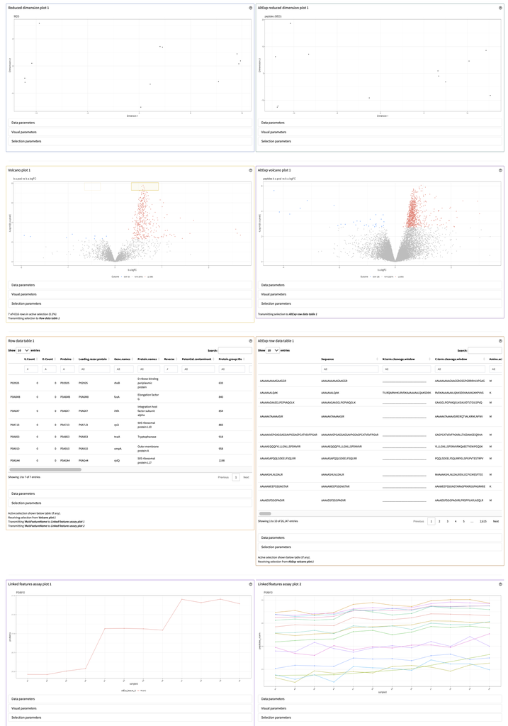

Note that you can

1. Select the proteins in the row data table using a part of their name or by selecting features in the volcanoplot
2. Look at the results of another protein by either selecting another protein in the row data table or in the dropdown menus of both linked feature plots
3. adjust the volcano plot for other contrasts e.g. c-a and c-b by selecting the corresponding p-value and log2 fold changes in the volcano plot panel.
4. also use the AltExp row data table to select features and the peptide altExp as the selection source in both panels. You can then select DA peptidoforms in the Alt Exp volcano plot, and visualise the peptidoform and its corresponding protein in their corresponding linked feature assay plots by selecting a peptidofrom from the AltExp row data table.

Note that you can also use the AltFeatureAssayPlot panels if you want to visualise features from the AltExp without the use of links, i.e. as the altExp counterpart of FeatureAssayPlots for the main experiment.